# The Elements of Statistical Learning - Hastie

# Chapter 2: Overview of Supervised Learning

## 2.3.2: Nearest-Neighbor Methods

The $k$-th nearest neighbor method for categorical classification is described as
$$\hat{Y}(x) = \frac{1}{k} \sum_{x_i\in N_k(x)} y_i$$
as described in 2.3.2. The neighborhood of $x$, defined as $N_k(x)$, represents the $k$ data points that are closest to the observed point using Euclidean distance. Thus, if we have two classification groups, $G = \{0, 1\}$, then $\hat{Y}(x)$ will represent the proportion of the $k$th closest points that are in group 1. We can then classify the point $x_i$ as group 1 if $\hat{Y} > 0.5$ and group 0 otherwise. Below is an implementation of the algorithm.

### Sample Data

First, a sample containing points for both groups is taken from different bivariate normal distributions similar to described in the book.

```r
m_kX1 <- sample(rep(1/10, 10)*(1:10)/2, size = 10, replace = TRUE)
m_kY1 <- sample(rep(1/10, 10)*(1:10)/2, size = 10, replace = TRUE)
m_kX2 <- sample(rep(1/10, 10)*(1:10)*2, size = 10, replace = TRUE)
m_kY2 <- sample(rep(1/10, 10)*(1:10)*2, size = 10, replace = TRUE)

sampleData <- rbind(data.frame(i = 1:10,
                                x = rnorm(10, mean = 1, sd = 1),
                                y = rnorm(10, mean = 0, sd = 1),
                                group = 1),
                     data.frame(i = 11:20,
                                x = rnorm(10, mean = 0, sd = 1),
                                y = rnorm(10, mean = 1, sd = 1),
                                group = 0),
                     data.frame(i = 21:30,
                                x = rnorm(m_kX1, mean = m_kX1, sd = 1/5),
                                y = rnorm(m_kY1, mean = m_kY1, sd = 1/5),
                                group = 1),
                     data.frame(i = 31:40,
                                x = rnorm(m_kX2, mean = m_kX2, sd = 1/5),
                                y = rnorm(m_kY2, mean = m_kY2, sd = 1/5),
                                group = 0))
```

The sample data can be plotted, where the label of the point represents the two groups.

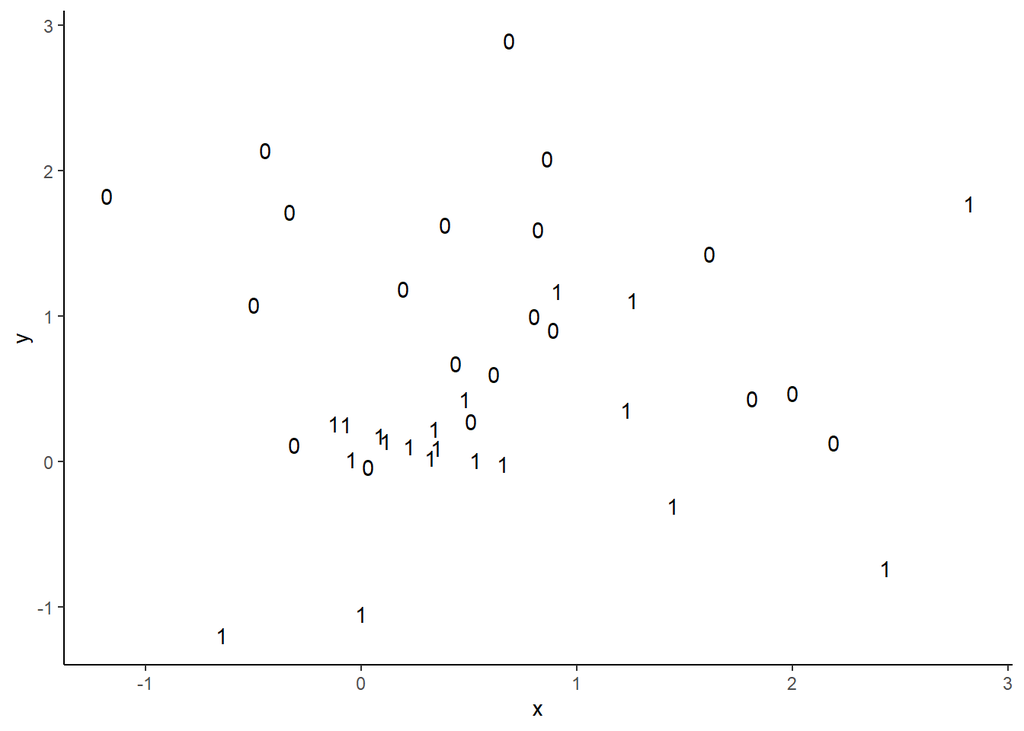

```r
sampleData %>%
  ggplot(aes(x = x, y = y)) +
  geom_text(aes(label = group)) +
  theme_bw() +
  theme(axis.line = element_line(colour = "black"),
        panel.grid.major = element_blank(),
        panel.grid.minor = element_blank(),
        panel.border = element_blank(),
        panel.background = element_blank(),
        legend.position = "none")
```

### Model

The model takes in an index $i$, $k$, and the sample data. First, the model finds the Euclidean distance from $x_i$ to all the other data points. Then, the model finds the $k$ closest points, and takes the mean of these points’ group. If the mean is greater than $\frac{1}{2}$, then $y_i = 1$, and otherwise $y_i = 0$.

```r
classifyByNearest <- function(index, k, sampleData){
  x_index <- sampleData[index, ]$x
  y_index <- sampleData[index, ]$y

  distances <- sampleData[sampleData$i != index, ] %>%
    summarise(i = i,
              dist = sqrt((x-x_index)^2 + (y - y_index)^2),
              group = group) %>%
    arrange(dist)

  classification <- ifelse(mean(distances[1:k, ]$group) > 0.5, 1, 0)

  return(classification)
}
```

The function is called for every data point with $k = 10$. The results are plotted, where the color now represents the model’s classification and helps visualize the neighborhood constructed, where the label of the point represents the actual group of the data point. A confustion matrix is then printed to show the classification results.

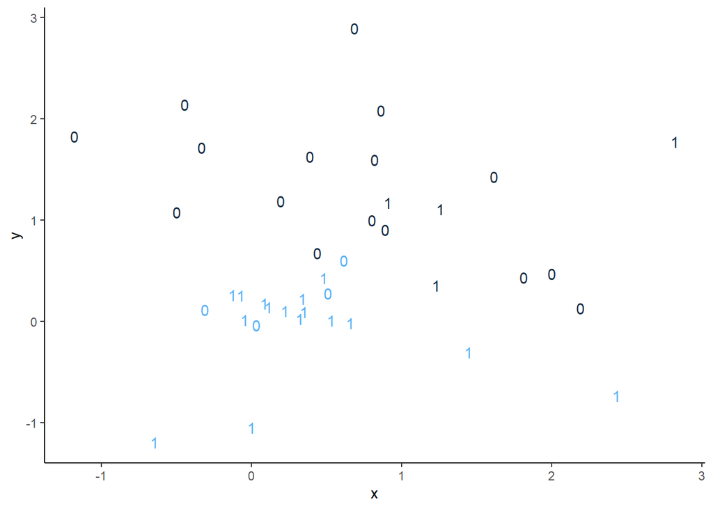

```r
k <- 10
sampleData$classification <- sapply(1:40, classifyByNearest, k = k, sampleData = sampleData)

sampleData %>%
  ggplot(aes(x = x, y = y, col = classification)) +
  geom_text(aes(label = group)) +
  theme_bw() +
  theme(axis.line = element_line(colour = "black"),
        panel.grid.major = element_blank(),
        panel.grid.minor = element_blank(),
        panel.border = element_blank(),
        panel.background = element_blank(),
        legend.position = "none")
```

```r
table(data.frame(actual = sampleData$group, prediction = sampleData$classification))
```

```
##       prediction
## actual  0  1
##      0 16  4
##      1  4 16
```